# Clustering For English Movies, The data source: IMDB

## Visualization of clusters

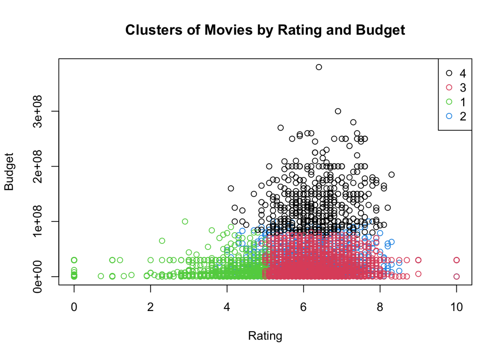

```r
# Visualize clusters by rating and budget
plot(movies_AR$Rate, movies_AR$Budget, col = movies_AR$cluster,
     xlab = "Rating", ylab = "Budget",
     main = "Clusters of Movies by Rating and Budget")
legend("topright", legend = unique(movies_AR$cluster), col = 1:max(movies_AR$cluster), pch = 1)
```

- we can see the results in a better way by ploting 3D plot

```r
# Install and load the necessary library for 3D scatter plots
# install.packages("scatterplot3d")
library(scatterplot3d)
```

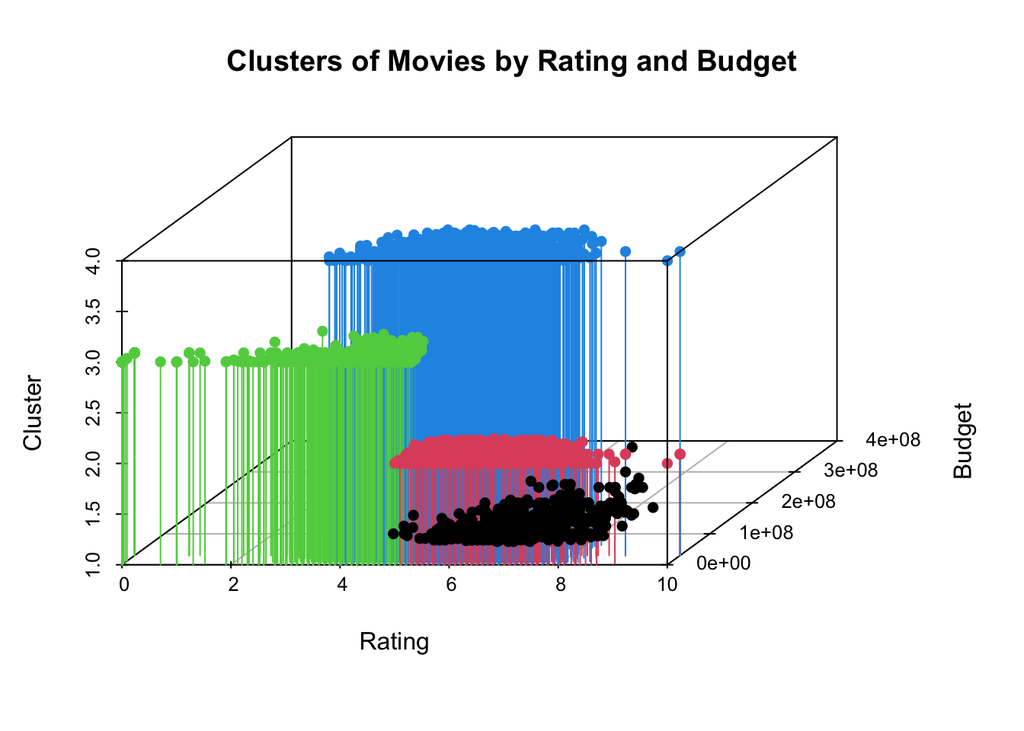

```r
# Create the 3D scatter plot
scatterplot3d(movies_AR$Rate, movies_AR$Budget, movies_AR$cluster,
              xlab = "Rating", ylab = "Budget", zlab = "Cluster",
              main = "Clusters of Movies by Rating and Budget",
              color = as.numeric(movies_AR$cluster),
              pch = 16,
              type = "h",
              angle = 55
)
```

These clusters are represented by different colors. The ‘Rating’ axis indicates the average rating of movies, likely on a scale of 0-10. The ‘Budget’ axis represents the production budget of movies and is scaled in scientific notation, for example, 4e+08 means a budget of 400 million units of currency. The ‘Cluster Axis’ denotes the cluster to which each movie has been assigned.

```r
# Aggregate data within each cluster to find mean ratings and budgets
aggregate(movies_AR[, c("Rate", "Budget")], by = list(movies_AR$cluster), FUN = mean)
```

```
##   Group.1     Rate    Budget
## 1       1 6.353265 133268614
## 2       2 6.289302  19853087
## 3       3 4.047786  11919834
## 4       4 6.161929  28255804
```

- The previous results represent the mean of rate and budget in every cluster, before we assigen them to Genres.
- Engaging Genre to every cluster

```r
# Extract relevant columns for cluster and genre
cluster_genre <- data.frame(Cluster = movies_AR$cluster, Genre = movies_AR$Genre)
```

```r
# How to find the highest and lowest genre in each cluster
find_high_low_genre <- function(cluster_data) {
  freq_genre <- table(cluster_data$Genre)
  highest_genre <- names(freq_genre)[which.max(freq_genre)]
  lowest_genre <- names(freq_genre)[which.min(freq_genre)]
  return(data.frame(Cluster = unique(cluster_data$Cluster), Highest_Genre = highest_genre, Lowest_Genre = lowest_genre))
}

# Apply the function to get a summary of highest and lowest genres in each cluster
genre_summary <- by(cluster_genre, cluster_genre$Cluster, find_high_low_genre)
# Convert the  object to a data frame
genre_summary_df <- do.call(rbind, lapply(genre_summary, data.frame))
```